# Classifiers: Discriminant Analysis and Regression Trees

11/15/2018

## Discriminant Analysis

## how it works

Consider 3 unclassified observations:

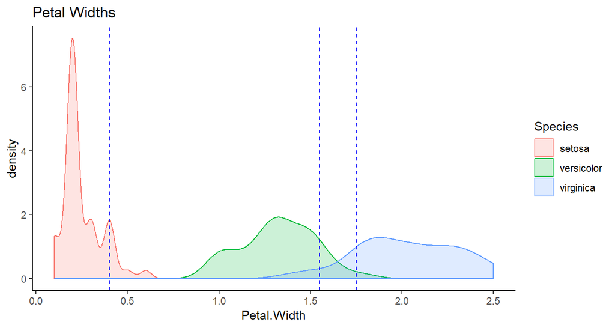

Classify each according to the largest density value at each co-ordinate.

## Fisher’s irises, again

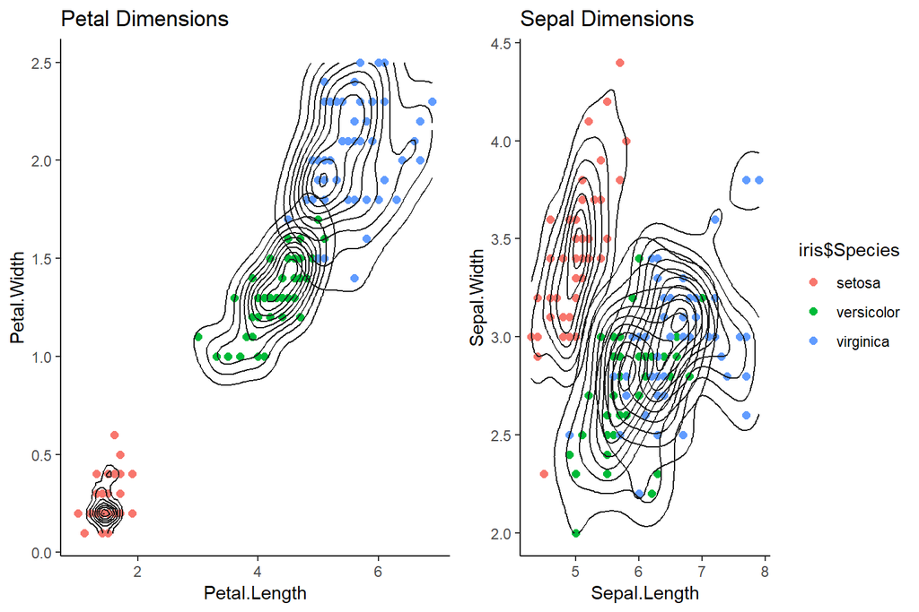

## linear discriminant analysis (LDA)

```r
summary(
  iris.lda <- lda(Species ~ Petal.Length+Petal.Width+Sepal.Length+Sepal.Width, data=iris)
)
```

```
##         Length Class  Mode
## prior    3     -none- numeric
## counts   3     -none- numeric
## means   12     -none- numeric
## scaling  8     -none- numeric
## lev      3     -none- character
## svd      2     -none- numeric
## N        1     -none- numeric
## call     3     -none- call
## terms    3     terms  call
## xlevels  0     -none- list
```

## check the fits

```
##
##                        setosa versicolor virginica Sum
##   predicted setosa         50          0         0  50
##   predicted versicolor      0         48         1  49
##   predicted virginica       0          2        49  51
##   Sum                      50         50        50 150
```

```
## misclassification rate
##                   0.02
```

## quadratic discriminant analysis (QDA)

An improvement over LDA, QDA does not assume the variance-covariance of the predictors are the same for all classes.

```r
summary(
  iris.qda <- qda(Species ~ Petal.Length+Petal.Width+Sepal.Length+Sepal.Width, data=iris)
)
```

```
##         Length Class  Mode
## prior    3     -none- numeric
## counts   3     -none- numeric
## means   12     -none- numeric
## scaling 48     -none- numeric
## ldet     3     -none- numeric
## lev      3     -none- character
## N        1     -none- numeric
## call     3     -none- call
## terms    3     terms  call
## xlevels  0     -none- list
```

## check the fits

```
##
##                        setosa versicolor virginica Sum
##   predicted setosa         50          0         0  50
##   predicted versicolor      0         48         1  49
##   predicted virginica       0          2        49  51
##   Sum                      50         50        50 150
```

```
## misclassification rate
##                   0.02
```

## regression trees

## how it works

- The algorithm examines each predictor to find the best value that partitions the data into homogeneous classes. Everitt and Hothorn (2006), pp.131-142
- Then it does the same thing in each partion
- Then it does the same thing in each partion of each partition
- Then it does the same thing…

```r
iris.rp <- rpart(Species ~ Petal.Width + Petal.Length + Sepal.Length + Sepal.Width, data=iris)
iris.rp$cptable
```

```
##     CP nsplit rel error xerror       xstd
## 1 0.50      0      1.00   1.21 0.04836666
## 2 0.44      1      0.50   0.72 0.06118823
## 3 0.01      2      0.06   0.09 0.02908608
```

## check the fits

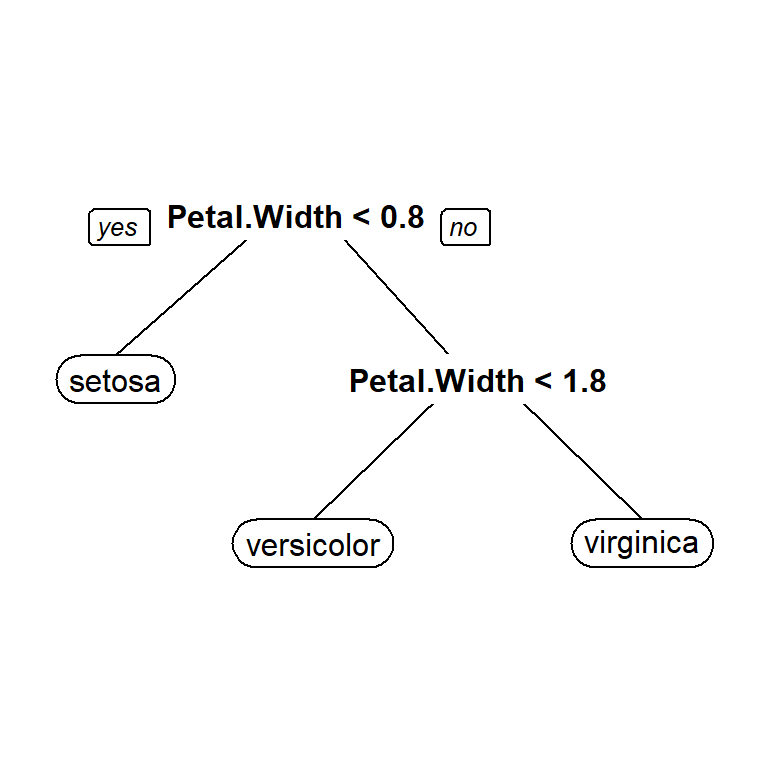

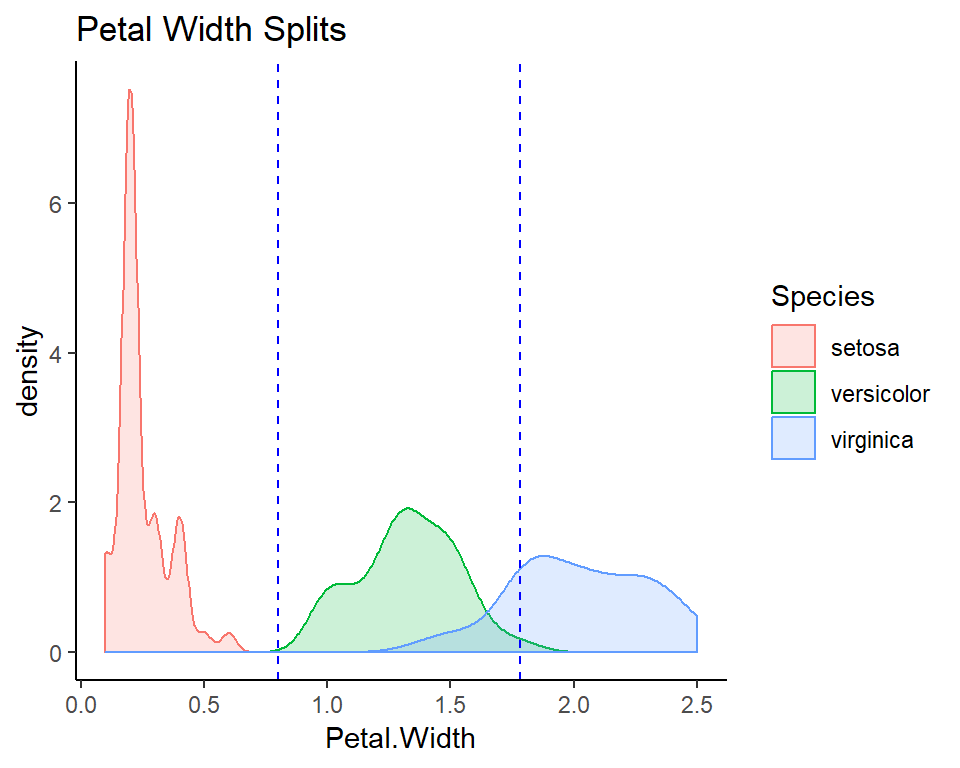

## fit statistics

```
##
## rp.pred      setosa versicolor virginica Sum
##   setosa         50          0         0  50
##   versicolor      0         49         5  54
##   virginica       0          1        45  46
##   Sum            50         50        50 150
```

```
## misclassification rate
##                   0.04
```

## classifier smackdown

[figure not shown]

## comparing classifiers

### training and test data sets

In practice, classifiers are evaluated using a “training-test” protocol. (Alice (2015))

- a data set is split into two parts
  - a **training set** and
  - a **test set**
- the model is fit to the training set
- then evaluated against the test set

```r
mg.data <- read.csv("mammographic_masses.csv", col.names = c("BI-RADS", "Age","Shape","Margin", "Density", "Severity"),na.strings="?")
mg.splits <- split_data(mg.data, c(0.8, 0.2), which.adjust = 2)
mg.training <- as.data.frame(mg.splits[1])
names(mg.training) <-c("BI.RADS", "Age", "Shape", "Margin", "Density", "Severity")
mg.test     <- as.data.frame(mg.splits[2])
names(mg.test)     <-c("BI.RADS", "Age", "Shape", "Margin", "Density", "Severity")
```

Let’s test some data on some mammogram data from Elter and Schltz-Wendtland (2007).

## logistic regression

```
## Call:
## multinom(formula = factor(Severity) ~ BI.RADS + Age + Shape +
##     Margin + Density, data = mg.training, maxit = 50)
##
## Coefficients:
##                    Values   Std. Err.
## (Intercept) -12.520868122 1.226751997
## BI.RADS       1.619402492 0.199152857
## Age           0.050901248 0.008869681
## Shape         0.436940183 0.113215022
## Margin        0.416450925 0.089826483
## Density       0.008447545 0.270913426
##
## Residual Deviance: 591.5015
## AIC: 603.5015
```

## how did we do?

```
##
## predicted_class  0  1
##               0 84 20
##               1 16 72
```

```
## misclassification rate
##                 0.1875
```

## discriminant analysis

```r
summary(
  lda.model <- lda(factor(Severity) ~ BI.RADS+Age+Shape+Margin+Density, data=mg.training)
)
```

```
##         Length Class  Mode
## prior    2     -none- numeric
## counts   2     -none- numeric
## means   10     -none- numeric
## scaling  5     -none- numeric
## lev      2     -none- character
## svd      1     -none- numeric
## N        1     -none- numeric
## call     3     -none- call
## terms    3     terms  call
## xlevels  0     -none- list
```

## how did we do?

```
##
##         0   1 Sum
##   0    82  18 100
##   1    18  74  92
##   Sum 100  92 192
```

```
## misclassification rate
##                 0.1875
```

## regression tree

```r
rp.model <- rpart(factor(Severity) ~ BI.RADS+Age+Shape+Margin+Density, data=mg.training)
rp.model$cptable
```

```
##           CP nsplit rel error    xerror       xstd
## 1 0.63068182      0 1.0000000 1.0000000 0.03922787
## 2 0.01420455      1 0.3693182 0.3693182 0.02952288
## 3 0.01136364      4 0.3238636 0.3806818 0.02987953
## 4 0.01000000      5 0.3125000 0.3664773 0.02943215
```

## how did we do?

```
##
## rp.pred   0   1 Sum
##     0    85  23 108
##     1    15  69  84
##     Sum 100  92 192
```

```
## misclassification rate
##              0.1979167
```

## and the winner is…

| classifier | miss.rate |
| --- | --- |
| logistic regression | 0.1875 |
| discriminant analysis | 0.1875 |
| regression tree | 0.1979 |

Can these be improved? No. And yes.

- NO: more data, but more importantly, more useful variables are needed.
- YES: classifiers can be improved by **boosting**, a *bootstrapping* technique
- REAL WORLD APPLICATION: “AI’s” are reading mammograms *right now*. And you know the trick.

## appendix:

### the code behind the examples

## you need these libraries

```r
knitr::opts_chunk$set(echo = FALSE, tidy=TRUE)
library(tidyverse)
library(gridExtra)
library(MASS)
library(rpart)
library(rpart.plot) # prp()
library(kableExtra)
```

## plot the iris data

```r
gPetal <- ggplot(data=iris, aes(x=Petal.Length, y=Petal.Width)) +
  geom_point( aes(color=iris$Species), size=2.0, show.legend=FALSE) +
  geom_density_2d(aes(group=Species), color="gray10") +
  labs(title="Petal Dimensions") +
  theme_classic()

gSepal <- ggplot(data=iris, aes(x=Sepal.Length, y=Sepal.Width)) +
  geom_point( aes(color=iris$Species), size=2.0, show.legend=TRUE) +
  geom_density_2d(aes(group=Species), color="gray10") +
  labs(title="Sepal Dimensions") +
  theme_classic()

grid.arrange(gPetal, gSepal, nrow=1, ncol=2)
```

## single-predictor discrimination

```r
data("iris")
ggplot(data=iris, aes(Petal.Width, fill=Species, color=Species)) +
  geom_density(alpha=0.2) +
  geom_vline(xintercept = c(0.4, 1.55, 1.75), color="blue", linetype="dashed") +
  labs(title="Petal Widths") +
  theme_classic()
```

## linear discriminant analysis

```r
summary(
  iris.lda <- lda(Species ~ Petal.Length+Petal.Width+Sepal.Length+Sepal.Width, data=iris)
)
```

```r
lda.pred <- predict(iris.lda)
F <- table(lda.pred$class, iris$Species)
rownames(F) <- paste0("predicted ", iris$Species%>% levels)
F %>% addmargins

miss.rate <- 1 - sum(diag(F))/length(iris$Species)
names(miss.rate) <- "misclassification rate"
miss.rate
```

## quadratic discriminant analysis

```r
summary(
  iris.qda <- qda(Species ~ Petal.Length+Petal.Width+Sepal.Length+Sepal.Width, data=iris)
)
```

```r
qda.pred <- predict(iris.qda)
F <- table(qda.pred$class, iris$Species)
rownames(F) <- paste0("predicted ", iris$Species%>% levels)
F %>% addmargins

miss.rate <- 1 - sum(diag(F))/length(iris$Species)
names(miss.rate) <- "misclassification rate"
miss.rate
```

## smackdown

### Dason’s splitter

**stackOverflow** contributer Dason’s clever function for splitting data frames.

```r
split_data <- function(dat, props = c(.8, .15, .05), which.adjust = 1){
  # Dason's splitter from stackOverflow
  #
  # Make sure proportions are positive and the adjustment isn't too big
  stopifnot(all(props >= 0), which.adjust <= length(props))

  # could check to see if the sum is 1, but this is easier
  props <- props/sum(props)
  n <- nrow(dat)
  # How large should each group be?
  ns <- round(n * props)
  # The previous step might give something that gives sum(ns) > n
  # so force the group specified in which.adjust to right size
  ns[which.adjust] <- n - sum(ns[-which.adjust])

  ids <- rep(1:length(props), ns)
  which.group <- sample(ids) # Shuffle ids to randomize groups
  split(dat, which.group)
}
```

Dason (2018)

## smackdown

### split the data

```r
mg.data <- read.csv("mammographic_masses.csv", col.names = c("BI-RADS", "Age","Shape","Margin", "Density", "Severity"),na.strings="?")
mg.splits <- split_data(mg.data, c(0.8, 0.2), which.adjust = 2)
mg.training <- as.data.frame(mg.splits[1])
names(mg.training) <-c("BI.RADS", "Age", "Shape", "Margin", "Density", "Severity")
mg.test     <- as.data.frame(mg.splits[2])
names(mg.test)     <-c("BI.RADS", "Age", "Shape", "Margin", "Density", "Severity")
```

## smackdown

### data cleaning

The mammogram data has more than its share of **NA** values, all for discrete variables. Here they are replaced with the *mode* value. Kephart’s mode calculation does the trick nicely:

```r
theMode <- function(x) {
  temp <- table(as.vector(x))
  return( as.numeric(names(temp)[temp==max(temp)]))
}
```

Kephart (2012)

```r
mg.training$BI.RADS[is.na(mg.training$BI.RADS)] <- theMode(mg.training$BI.RADS)
mg.training$Age[is.na(mg.training$Age)] <- theMode(mg.training$Age)
mg.training$Shape[is.na(mg.training$Shape)] <- theMode(mg.training$Shape)
mg.training$Margin[is.na(mg.training$Margin)] <- theMode(mg.training$Margin)
mg.training$Density[is.na(mg.training$Density)] <- theMode(mg.training$Density)

mg.test$BI.RADS[is.na(mg.test$BI.RADS)] <- theMode(mg.test$BI.RADS)
mg.test$Age[is.na(mg.test$Age)] <- theMode(mg.test$Age)
mg.test$Shape[is.na(mg.test$Shape)] <- theMode(mg.test$Shape)
mg.test$Margin[is.na(mg.test$Margin)] <- theMode(mg.test$Margin)
mg.test$Density[is.na(mg.test$Density)] <- theMode(mg.test$Density)
```

## smackdown

### logistic regression

```r
library(nnet)
summary(
  logreg.model <- multinom(factor(Severity) ~ BI.RADS+Age+Shape+Margin+Density,
                           data=mg.training, maxit=50)
)
```

```r
predicted_class <- predict(logreg.model, mg.test)

( T <- table(predicted_class, mg.test$Severity) )
log.reg.miss.rate <- 1 - sum(diag(T))/length(mg.test$Severity)
names(log.reg.miss.rate) <- "misclassification rate"
log.reg.miss.rate
```

## smackdown

### discriminant analysis

```r
summary(
  lda.model <- lda(factor(Severity) ~ BI.RADS+Age+Shape+Margin+Density, data=mg.training)
)
```

```r
lda.pred <- predict(lda.model, mg.test)
F <- table(lda.pred$class, mg.test$Severity)
F %>% addmargins

lda.miss.rate <- 1 - sum(diag(F))/length(mg.test$Severity)
names(lda.miss.rate) <- "misclassification rate"
lda.miss.rate
```

## smackdown

### regresssion tree

```r
rp.model <- rpart(factor(Severity) ~ BI.RADS+Age+Shape+Margin+Density, data=mg.training)
rp.model$cptable
```

```r
library(rpart)
rp.pred <- predict(rp.model, newdata=mg.test, type="class")
F <- table(rp.pred, mg.test$Severity)
F %>% addmargins

rp.miss.rate <- 1 - sum(diag(F))/length(mg.test$Severity)
names(rp.miss.rate) <- "misclassification rate"
rp.miss.rate
```

## smackdown

### mis-classification summary

```r
smackdown.stats <- data.frame(classifier = c("logistic regression", "discriminant analysis", "regression tree"),
                              miss.rate = c(log.reg.miss.rate, lda.miss.rate, rp.miss.rate))
smackdown.stats %>%
  mutate(., miss.rate=signif(miss.rate, 4)) %>%
  kable(., format = "html", escape=F) %>%
  kable_styling(full_width=F, position = 'center')
```

## references

### …to learn more

Alice, Michy. 2015. “How to Perform a Logistic Regression in R.” DataScience+ web site. 2015. https://datascienceplus.com/perform-logistic-regression-in-r/.

Dason. 2018. “**split_data()**.” 2018. https://stackoverflow.com/questions/20041239/how-to-randomly-split-a-data-frame-into-three-smaller-ones-with-given-numbers-of.

Elter, Matthias, and Rudiger Schltz-Wendtland. 2007. “Mammographic Mass Data Set.” 2007. https://archive.ics.uci.edu/ml/datasets/Mammographic+Mass.

Everitt, Brian S., and Torsetn Hothorn. 2006. *A Handbook of Statistical Analyses Using R*. Abington UK: Chapman; Hall/CRC.

Kephart, Curtis. 2012. “Finding the Mode of a Variable in R.” 2012. http://www.cazaar.com/ta/econ113/mode-code-for-r.